# Overview of Statistical Elements and Tests

Samuel Vincent

# Versions

- V1: Added general information on statistical elements and tests.
- V2: Created initial code blocks.
- V3: Revising code blocks for efficacy.
- V4: Combined general information and code blocks into the same section.
  - V4.1: Added some more text for the preface and end material, as well as a new “Useful Packages in R” section in the preface.
  - V4.2: Updated code block annotations.

# Preface

This R Notebook will contain information on various elements and tests used in statistical analyses. These will include t-tests, Wilcoxon tests, ANOVA, linear regressions and correlation tests, as well as elements such as hypotheses and p-values. In addition, I will be covering when it is appropriate to use each test and the assumptions of each one. Finally, I will be covering four types of data visualization methods: histograms, box plots, heat maps and pie charts. I believe this will be a valuable asset for future statistical analyses on my end.

In addition to a general review of these elements, I will be covering blocks of R code that correspond to each element. This way, I can refer to this notebook in the likely case that I need to run a statistical test in R. These will come at the end of each test’s and data visualizsation’s section.

## Useful Packages in R

Base R is very helpful on its own for gathering and analyzing data, but sometimes we prefer to quicken the process by installing some external R code, known as **packages**. Two of the more prominent ones we like to use include:

- **ggplot2**: Used primarily to enhance data visualization with extra customization options.
- **plotrix**: Used for increasing R’s range of statistical functions, saving extra time.

# The Primary Statistical Tests

As mentioned before, the primary statistical tests are the t-test, Wilcoxon test, ANOVA, linear regression and correlation tests. These are the tools with which a data analyst will derive meaningful information from raw data. Statisticians can use these tests to gather vital information in order to piece graphs and results together.

## T-tests

### Overview

**T-tests** (or Student’s T-tests) are used to determine the difference of **two means**, each from a different group. These are generally the first type of statistical test one will learn about, as it is the most frequently-used type. It only relies on a singular numerical variable, as opposed to multiple variables.

It was initially created by **William S. Gosset**, an English statistician employed at the Guinness Brewery in Dublin. By the 1970s, this test was available in most software statistical packages.[^1]

### Assumptions

- When using a t-test, we have to assume:
  - The data follows a normal distribution
  - Observations of one group are independent of observations of the other
  - There are equal variances in the data

### When to Use It

T-tests should be used in scenarios where there are only two groups to derive means from. These can be two measurements of the same entity, or it can involve two entities that are being measured with unique properties or conditions.

### Hypotheses

- When using a t-test, the null and alternative hypotheses are:
  - Ho: There is not a difference between the two groups’ means
  - Ha: There is a significant difference between the two groups’ means

### Coding Process

R Studio stands out among other programming languages in its ability to perform data analysis tests. Here, we can insert a code block with a method of performing a t-test.

There are three types of t-tests you can perform in R: One-sample, two-sample and paired. For the one-sample t-test, we include a known value (in this case, 3.5), making this code expressed as:

```r
# Assigning a list to a group
data <- c(1,2,3,4,5)

# Performing a one-sample t-test
t.test(data, mu = 3.5)
```

```
##
##  One Sample t-test
##
## data:  data
## t = -0.70711, df = 4, p-value = 0.5185
## alternative hypothesis: true mean is not equal to 3.5
## 95 percent confidence interval:
##  1.036757 4.963243
## sample estimates:
## mean of x
##         3
```

For a two-sample t-test, we could write something like this. In this instance, we assume the variances between the two groups to be equal, indicated by the argument “var.equal = TRUE”. We use this type of t-test to compare two **independent** groups:

```r
# Assigning lists to groups
group_one <- c(1,3,5,7,9)
group_two <- c('A','B','C','D','E')
group_three <- c(0,2,4,6,8)

# Performing the two-sample t-test
t.test(group_one, group_three, var.equal = TRUE)
```

```
##
##  Two Sample t-test
##
## data:  group_one and group_three
## t = 0.5, df = 8, p-value = 0.6305
## alternative hypothesis: true difference in means is not equal to 0
## 95 percent confidence interval:
##  -3.612008  5.612008
## sample estimates:
## mean of x mean of y
##         5         4
```

And finally, for a paired t-test, we can write something along the lines of this. Unlike the previous type, this is used to compare two **related** groups:

```r
# Assigning lists to more groups
group_before <- c(1,3,5,7,9)
group_after <- c(7,23,78,12,7)

# Performing the paired t-test
t.test(group_before, group_after, paired = TRUE)
```

```
##
##  Paired t-test
##
## data:  group_before and group_after
## t = -1.4972, df = 4, p-value = 0.2087
## alternative hypothesis: true mean difference is not equal to 0
## 95 percent confidence interval:
##  -58.23104  17.43104
## sample estimates:
## mean difference
##           -20.4
```

## Wilcoxon Tests

### Overview

The **Wilcoxon test** (a.k.a. Wilcoxon signed rank test) is similar to the t-test, with one significant difference: it is **nonparametric**. This means that the test doesn’t assume that the data follows a distribution.[^2]

This test was created by **Frank Wilcoxon** in 1945, in the same scientific paper that also presented the rank-sum test. It was popularized by American psychologist and statistician Sidney Siegel in 1965.[^3]

### Assumptions

- When performing a Wilcox test, we assume:
  - The data follows no particular distribution

### When to Use It

Statisticians will use Wilcox tests when the above assumption is true. In addition to this, this is preferred over t-tests because of increased power through its ability to analyze **ordinal data** (data that is categorized but differences between each category aren’t identifiable) and reduce outlier impact.

### Hypotheses

Since there are two types of Wilcox tests, one-sample and paired, there are a pair of null and alternative hypotheses for each one.

- For the one-sample test:
  - Ho: The population median is the same as the benchmark value
  - Ha: The population median is significantly different from the benchmark value
- For the paired test:
  - Ho: The median of the paired differences cancel each other out (=0) in the overall population
  - Ha: The median of the paired differences don’t equal zero in the overall population

### Coding Process

Similarly to the t-tests, Wilcoxon tests come in three flavors for the sake of R: Signed-rank tests, rank-sum tests and one-sample tests. Signed-rank tests are used typically to compare data of two **related** samples. This could be expressed as:

```r
# Assigning before-and-after lists to two groups
group_before <- c(1,3,5,7,9)
group_after <- c(0,2,4,6,8)

# Performing a signed-rank wilcox test
wilcox.test(group_before, group_after, paired = TRUE)
```

```
##
##  Wilcoxon signed rank test with continuity correction
##
## data:  group_before and group_after
## V = 15, p-value = 0.03689
## alternative hypothesis: true location shift is not equal to 0
```

Rank-sum tests are used to compare two **independent** samples of data. In this case, such a test could be written like:

```r
# Assigning two independent sets of data to two groups
group_one <- c(1,3,5,7,9)
group_two <- c(4,8,45,21,92,12)

# Performing a rank-sum wilcox test
wilcox.test(group_one, group_two, paired = FALSE)
```

```
##
##  Wilcoxon rank sum exact test
##
## data:  group_one and group_two
## W = 4, p-value = 0.05195
## alternative hypothesis: true location shift is not equal to 0
```

```r
# Keep in mind that the only difference between the sign-rank and rank-sum tests are whether you mark the "paired" argument as TRUE or FALSE.
```

Lastly, we use one-sample test to determine whether the median of one sample deviates from a known value (in this case, 3.2):

```r
# Assigning a list to a group
sample <- c(1,2,3,4,5,11,24,31)

# Performing a one-sample wilcox test
wilcox.test(sample, mu = 3.2)
```

```
##
##  Wilcoxon signed rank exact test
##
## data:  sample
## V = 27, p-value = 0.25
## alternative hypothesis: true location is not equal to 3.2
```

## ANOVA

### Overview

The **ANOVA** (a.k.a. Analysis of Variance) test is used to see of the means of **three or more groups** for significant differences among them.[^4] This assists statisticians with determining whether differences observed in the groups’ means are due to chance or caused by true effects of the property applied to them. This makes it similar to the t-test, only it has the capacity for 3+ groups’ means.

This test was devised by **R. A. Fisher**, a British statistician, in 1918. It was developed using the t-test as a reference point, which explains its similarities.[^5]

### Assumptions

- When utilizing an ANOVA, we assume:
  - The data follows a normal distribution
  - Observations of one group are independent of observations of the other
  - There are equal variances in the data

Note that these assumptions are the same as with a t-test.

### When to Use It

People typically use ANOVA tests when there are three or more groups of data from which means can be derived. By grouping all of these data together, this consequently reduces the risk of false significance in the results.

### Hypotheses

- The null and alternative hypotheses of an ANOVA test are almost the same as with a t-test, which are:
  - Ho: There is no difference between the means of the 3+ groups of data
  - Ha: There is a significant difference between the means of the 3+ groups of data. More specifically, at least one group of data contains a significantly-different mean from the others

### Coding Process

There are two types of ANOVA tests we can perform in R: one-way and two-way. We use the former whenever we have one **categorical, independent** variable and one **continuous, dependent** variable:

```r
# Assigning a data frame to a variable, creating parameters for the ANOVA test
# rnorm stays the same, while the means from each group can differ.
data <- data.frame(
  group = rep(c('A', 'B', 'C'), each = 10),
  value = c(rnorm(10, mean = 2), rnorm(10, mean = 5), rnorm(10, mean = 8))
)

# Performing a one-way ANOVA test, displaying the result
anova_result <- aov(value ~ group, data = data)
anova_result
```

```
## Call:
##    aov(formula = value ~ group, data = data)
##
## Terms:
##                     group Residuals
## Sum of Squares  201.32113  21.19264
## Deg. of Freedom         2        27
##
## Residual standard error: 0.8859528
## Estimated effects may be unbalanced
```

For the two-way ANOVA, this is used whenever there are **two** categorical, independent variables. This can be written out as:

```r
# Assigning a data frame to a variable, specifying parameters for each group
data <- data.frame(
  group1 = rep(c("A", "B"), each = 5),
  group2 = rep(c("Y", "Z"), times = 5),
  value = c(rnorm(5, mean = 5), rnorm(5, mean = 4.5), rnorm(5, mean = 3), rnorm(5, mean = 2.5))
)

# Performing a two-way ANOVA test, displaying the result
anova_result_2way <- aov(value ~ group1 * group2, data = data)
anova_result_2way
```

```
## Call:
##    aov(formula = value ~ group1 * group2, data = data)
##
## Terms:
##                    group1    group2 group1:group2 Residuals
## Sum of Squares   3.280218  0.023823      0.311601 30.148037
## Deg. of Freedom         1         1             1        16
##
## Residual standard error: 1.372681
## Estimated effects may be unbalanced
```

```r
# The only difference between the two types is whether you set your value up with only one group, or two.
```

## Linear Regression

### Overview

**Linear regression** is a statistical model that details the relationships between at least one **explanatory variable** (any variable that predicts changes in another variable[^6]) and an **outcome variable** (the variable that’s being affected by the explanatory variable[^7]). [^8]

It is one of the earliest types of regression analyses.

### Assumptions

- When conducting a linear regression analysis, we assume:
  - Normal distribution of data
  - A linear formula fits the variables’ relationship
  - Constant scattering among residuals
  - Any observations of the data are independent from each other

### When to Use It

Linear regression analyses are used when the relationship between variables are desired, as well as when this relationship is thought to be represented by a linear formula, such as y=mx+b. This in turn serves to predict changes in certain variables by changes in others, the basis of clinical research.

### Hypotheses

- The null and alternative hypotheses of the linear regression analysis are:
  - Ho: The slope of the population equals zero (in the formula y=β₀+β₁+ε ). The hypotheses focus on the status of β₁ in this instance[^9]
  - Ha: The slope of the population doesn’t equal zero

### Coding Process

For performing the linear regression, we will use a base data set, “mtcars” for the purpose of this exercise. Keep in mind that there are multiple steps, however; We can write an instance of this out as:

```r
# Loading in and inspecting data and related packages
library(ggplot2)
data(mtcars)
head(mtcars)
```

|  | mpg | cyl | disp | hp | drat | wt | qsec | vs | am | gear | carb |
| --- | --- | --- | --- | --- | --- | --- | --- | --- | --- | --- | --- |
| Mazda RX4 | 21.0 | 6 | 160 | 110 | 3.90 | 2.620 | 16.46 | 0 | 1 | 4 | 4 |
| Mazda RX4 Wag | 21.0 | 6 | 160 | 110 | 3.90 | 2.875 | 17.02 | 0 | 1 | 4 | 4 |
| Datsun 710 | 22.8 | 4 | 108 | 93 | 3.85 | 2.320 | 18.61 | 1 | 1 | 4 | 1 |
| Hornet 4 Drive | 21.4 | 6 | 258 | 110 | 3.08 | 3.215 | 19.44 | 1 | 0 | 3 | 1 |
| Hornet Sportabout | 18.7 | 8 | 360 | 175 | 3.15 | 3.440 | 17.02 | 0 | 0 | 3 | 2 |
| Valiant | 18.1 | 6 | 225 | 105 | 2.76 | 3.460 | 20.22 | 1 | 0 | 3 | 1 |

```r
summary(mtcars)
```

```
##       mpg             cyl             disp             hp
##  Min.   :10.40   Min.   :4.000   Min.   : 71.1   Min.   : 52.0
##  1st Qu.:15.43   1st Qu.:4.000   1st Qu.:120.8   1st Qu.: 96.5
##  Median :19.20   Median :6.000   Median :196.3   Median :123.0
##  Mean   :20.09   Mean   :6.188   Mean   :230.7   Mean   :146.7
##  3rd Qu.:22.80   3rd Qu.:8.000   3rd Qu.:326.0   3rd Qu.:180.0
##  Max.   :33.90   Max.   :8.000   Max.   :472.0   Max.   :335.0
##       drat             wt             qsec             vs
##  Min.   :2.760   Min.   :1.513   Min.   :14.50   Min.   :0.0000
##  1st Qu.:3.080   1st Qu.:2.581   1st Qu.:16.89   1st Qu.:0.0000
##  Median :3.695   Median :3.325   Median :17.71   Median :0.0000
##  Mean   :3.597   Mean   :3.217   Mean   :17.85   Mean   :0.4375
##  3rd Qu.:3.920   3rd Qu.:3.610   3rd Qu.:18.90   3rd Qu.:1.0000
##  Max.   :4.930   Max.   :5.424   Max.   :22.90   Max.   :1.0000
##        am              gear            carb
##  Min.   :0.0000   Min.   :3.000   Min.   :1.000
##  1st Qu.:0.0000   1st Qu.:3.000   1st Qu.:2.000
##  Median :0.0000   Median :4.000   Median :2.000
##  Mean   :0.4062   Mean   :3.688   Mean   :2.812
##  3rd Qu.:1.0000   3rd Qu.:4.000   3rd Qu.:4.000
##  Max.   :1.0000   Max.   :5.000   Max.   :8.000
```

```r
# Performing a linear regression
# Format: model <- lm(dep_variable ~ indep_variable, data = df)
model <- lm(mpg ~ wt, data = mtcars)
```

Next, we can visualize this model with the following code:

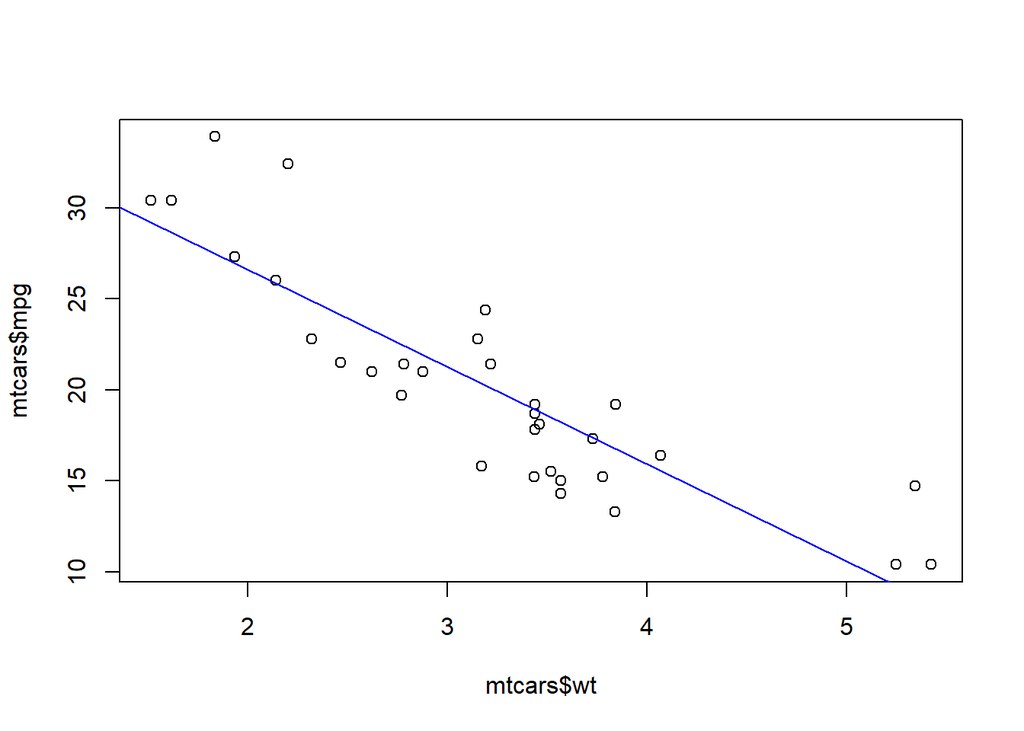

```r
# Constructing a graph for the linear regression results
plot(mtcars$wt, mtcars$mpg)
abline(model, col = "blue") # This can be any color you want.
```

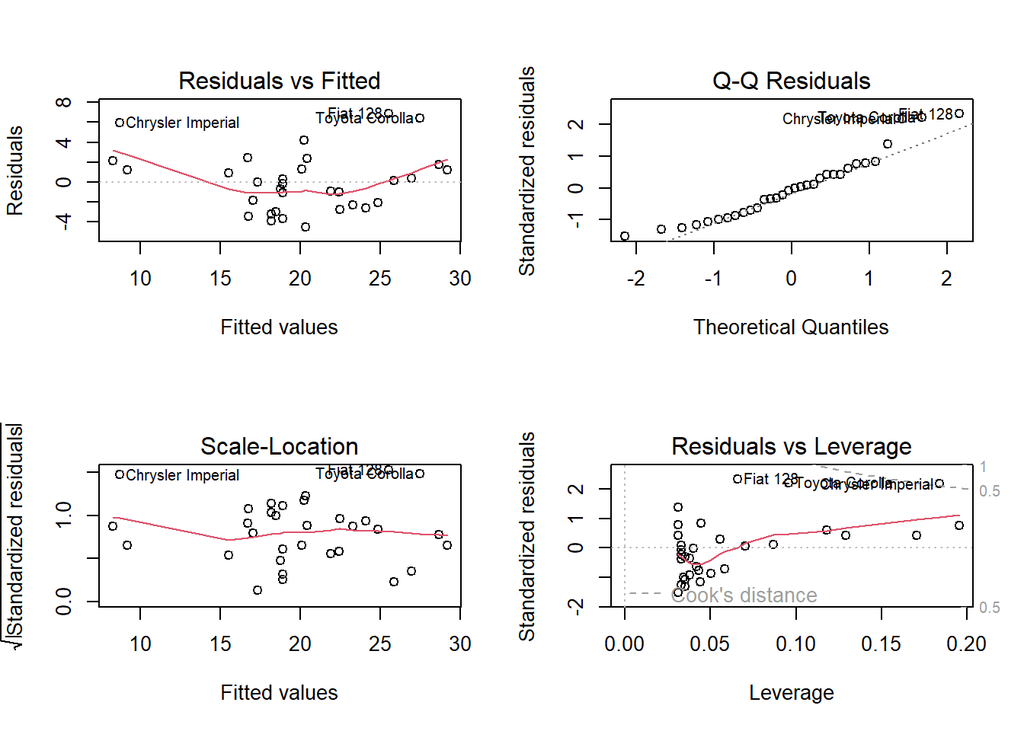

```r
# If you're performing a multiple regression test, you can try a diagnostic plot, which looks like...
par(mfrow = c(2, 2))
plot(model)
```

Finally, we can use this test to predict new values with the help of the predict() function. We can achieve this through writing the following code. As you can see by the result, the predicted miles per gallon would be 10.56.

```r
# Using the linear regression results to predict a value, displaying the result
new_data <- data.frame(wt = 5.0)  # We're using an example weight of 5k pounds, hence the 5.0
mpg_predictions <- predict(model, newdata = new_data)
mpg_predictions
```

```
##        1
## 10.56277
```

## Correlation Test

### Overview

The **correlation test** (a.k.a. correlation hypothesis test) is used to determine the strength and direction of the relationship between two variables.[^10] This statistical test does this through use of the correlation coefficient and sample size.

### Assumptions

- When using this test, we assume:
  - Normal data distribution
  - A linear relationship between two variables of interest[^11]
  - Minimal outliers

### When to Use It

We use the correlation hypothesis test when we want to determine whether the relationship between two non-outcome variables is significant or not.[^12] This makes it similarly useful in clinical trials, compared to linear regression analyses.

### Hypotheses

- The null and alternative hypotheses of this test are:
  - Ho: There isn’t a significant linear relationship between the two variables in question
  - Ha: The relationship between these two variables is both linear and significant. There is an identifiable correlation between them

### Coding Process

There are three methods we can use when performing correlation tests in R: ‘pearson’, ‘spearman’ and ‘kendall’. We use the pearson method when we’re dealing with **linear relationships** between target variables, the spearman method when we’re dealing with **monotonic**[^13] relationships, and the kendall method for **ordinal data**[^14] . We can write these out as:

```r
# The pearson method
x <- c(1,2,3,4,5)
y <- c(0,2,4,6,8)
p_result <- cor.test(x, y, method = "pearson")

# The spearman method
x <- c(1,2,3,4,5)
y <- c(0,2,4,6,8)
s_result <- cor.test(x, y, method = "spearman")

# The kendall method
x <- c(1,2,3,4,5)
y <- c(0,2,4,6,8)
k_result <- cor.test(x, y, method = "kendall")

# Displaying a given result
p_result
```

```
##
##  Pearson's product-moment correlation
##
## data:  x and y
## t = 82191237, df = 3, p-value < 2.2e-16
## alternative hypothesis: true correlation is not equal to 0
## 95 percent confidence interval:
##  1 1
## sample estimates:
## cor
##   1
```

# The Primary Statistical Elements

Alongside statistical tests, there are two important elements present in virtually all quantitative analyses: the **hypotheses** and **p-value**. The former are developed towards the start of the experiment/study, and the latter is derived towards the end as part of the results. Without them, no one would be able to put forth meaningful information through such scientific endeavors.

To this end, I will provide information on these elements. I hope to keep this so I can look back on it in the future.

## The Hypotheses

The hypotheses are composed of both the null and alternative hypotheses. These are devised in order to determine the potential outcomes of a given study/experiment/trial/etc. It’s similar to a traditional scientific hypothesis, with the difference being that these outcomes are listed in the most statistically-technical manner possible, to prevent assumptions on the potential results. I’ve already described various hypotheses in the previous section, but I will go over each type in greater detail here.

### Null Hypothesis

The **null hypothesis** (commonly referred to as “h<sub>o</sub>” or “ho”) will always state that there are no differences between sets of data, whether this is before and after a treatment, when comparing statistical values of different sets of data, etc. Even if differences are found, the h<sub>o</sub> will write this off as a result of random error/variation in the data sets.

### Alternative Hypothesis

The **alternative hypothesis** (referred to as “h<sub>a</sub>” or “ha”) will state the opposite of the former’s proposition. This means that any differences found in data sets after performing the necessary tests are a result of direct, intentional intervention. In other words, if a clinical trial was being conducted, this hypothesis will state that the treatment being applied to the experimental group is directly affecting the results.

### Making a Decision

When determining the final results of your experiment/study, you’ll need to either **reject the h<sub>o</sub> or accept it**. The former signifies that you’ve determined that a difference was made because of the applied treatment, while the latter means that you’ve determined that there was no actual difference in the populations.[^15]

### Coding Process

We can set up logical systems to facilitate the integration of these elements in R. We can try out a way to do this with both of them in one code block, since they can only exist in the context of each other. Now, let’s try this setup with some data from the mtcars data frame. We can use data from the mpg column for this:

```r
# Loading in and inspecting the data
options(repos = c(CRAN="https://cloud.r-project.org")) # sets up CRAN mirror
update.packages(ask = FALSE)
```

[output not shown]

[output not shown]

[output not shown]

[output not shown]

```r
install.packages("plotrix")
library(plotrix)
data <- data(mtcars)
summary(mtcars)
```

```
##       mpg             cyl             disp             hp
##  Min.   :10.40   Min.   :4.000   Min.   : 71.1   Min.   : 52.0
##  1st Qu.:15.43   1st Qu.:4.000   1st Qu.:120.8   1st Qu.: 96.5
##  Median :19.20   Median :6.000   Median :196.3   Median :123.0
##  Mean   :20.09   Mean   :6.188   Mean   :230.7   Mean   :146.7
##  3rd Qu.:22.80   3rd Qu.:8.000   3rd Qu.:326.0   3rd Qu.:180.0
##  Max.   :33.90   Max.   :8.000   Max.   :472.0   Max.   :335.0
##       drat             wt             qsec             vs
##  Min.   :2.760   Min.   :1.513   Min.   :14.50   Min.   :0.0000
##  1st Qu.:3.080   1st Qu.:2.581   1st Qu.:16.89   1st Qu.:0.0000
##  Median :3.695   Median :3.325   Median :17.71   Median :0.0000
##  Mean   :3.597   Mean   :3.217   Mean   :17.85   Mean   :0.4375
##  3rd Qu.:3.920   3rd Qu.:3.610   3rd Qu.:18.90   3rd Qu.:1.0000
##  Max.   :4.930   Max.   :5.424   Max.   :22.90   Max.   :1.0000
##        am              gear            carb
##  Min.   :0.0000   Min.   :3.000   Min.   :1.000
##  1st Qu.:0.0000   1st Qu.:3.000   1st Qu.:2.000
##  Median :0.0000   Median :4.000   Median :2.000
##  Mean   :0.4062   Mean   :3.688   Mean   :2.812
##  3rd Qu.:1.0000   3rd Qu.:4.000   3rd Qu.:4.000
##  Max.   :1.0000   Max.   :5.000   Max.   :8.000
```

```r
# Now we know that the population mean of the cars' mpgs equals 20.09; However, we also need a sample mean for this model to work. To this end, let's take a sample of the mpg values belonging to the first 3 cars in the list
population_mean_cars <- 20.09
sample_mean_cars <- ((21.0 + 21.0 + 22.8)/3)

# We also need standard error, which needs a standard deviation value. We can calculate these values by the following code and by using the neat plotrix package installed at the start
mpg_column <- mtcars$mpg
mpg_column
```

```
##  [1] 21.0 21.0 22.8 21.4 18.7 18.1 14.3 24.4 22.8 19.2 17.8 16.4 17.3 15.2 10.4
## [16] 10.4 14.7 32.4 30.4 33.9 21.5 15.5 15.2 13.3 19.2 27.3 26.0 30.4 15.8 19.7
## [31] 15.0 21.4
```

```r
se_mpg <- std.error(mpg_column)

# Finally, we can determine the z-score and p-value
z_score_mpg <- (sample_mean_cars - population_mean_cars) / se_mpg
p_value_mpg <- 2 * pnorm(-abs(z_score_mpg))

# Setting up the logical system, displaying the result
if(p_value_mpg <= 0.05) {
  result_mpg <- print("The results indicate rejection of the Null Hypothesis!")
} else if(p_value_mpg > 0.05) {
  result_mpg <- print("The results indicate acceptance of the Null Hypothesis!")
}
```

```
## [1] "The results indicate acceptance of the Null Hypothesis!"
```

```r
result_mpg
```

```
## [1] "The results indicate acceptance of the Null Hypothesis!"
```

Keep in mind that this is only one of many ways you can setup a logical system to help you make your final decision. This was just one of the more basic ways. You can plug in just about any test you want in the first portion of the code block, and go from there.

## P-Values

While the null and alternative hypotheses are integral to setting up an experiment, **p-values** (a.k.a. probability values) are equally as such when closing one out. A p-value is the measure of confidence, or likelihood, of obtaining the same set of data when performing the experiment/study under the assumption of the h<sub>o</sub>.[^16] In other words, a smaller p-value points more strongly to the h<sub>a</sub>. This makes obtaining as small of a p-value as possible desirable among researchers.

While people generally try getting their p-values as small as possible (unless you’ve set out to disprove previous studies), a rule of thumb is that a p-value of 0.05 or less is considered sufficiently likely that the h<sub>a</sub> is the true conclusion. This condition is known as **statistical significance**; If your experiment yields a p-value ≤ 0.05, it is considered statistically-significant. This is very good news if you’re conducting a clinical trial! In this case, it would mean your treatment has a noticeable effect in the subjects, and can’t reasonably be written off as random data variation.

# Visualizing Data

As demonstrated, there is a multitude of ways data can be manipulated to reach a desired result. However, it’s almost just as important to be able to show yourself and others these data in an easier-to-digest form. No one wants to shovel through a sea of numbers to see what you’re trying to prove. This is where **data visualization** comes in. Data visualization enables your peers to see the results of your efforts more easily.

There are four primary methods of displaying such data, with each one depending on the nature of the data: **histograms, box plots, heat maps and pie charts**. I will be covering each one in the upcoming material.

## Histograms

### Overview

Histograms consist mainly of x and y-axes, combined with boxes of various lengths lined up horizontally; Legends and trend-lines usually compliment this as well. These are used to display how data is distributed.[^17]. Due to the nature of histograms, they’re commonly used to help visualize trends in a set of data across a continuous interval, or period.

The difference between histograms and **bar charts** is a matter of the properties of the displayed data. While bar charts show categorical data with no need to display the period over which the data exists, histograms display how one set of data exists over a continuous interval, as stated before. The chunk of period a statistician will cut out for a histogram is called a **bin**.

Here is a link to an image of a typical histogram: https://www.geeksforgeeks.org/maths/histogram/

### Terms to Know

- Statistical entities associated with histograms include:
  - **Central tendency**: Which value the majority of recorded samples fall into. This is represented as a peak in the histogram. There can be more than one peak, depending on data.[^18]
  - **Symmetry**: The bars on a histogram chart can either be of the same frequency on both sides of the peak, or it can tend towards one side.
  - **Variability**: A measure of how much of a peak the chart displays. More variability yields a less-defined, more rounded-out peak.

### Coding Process

We can code for a histogram by using the **hist()** function and inserting placeholder data:

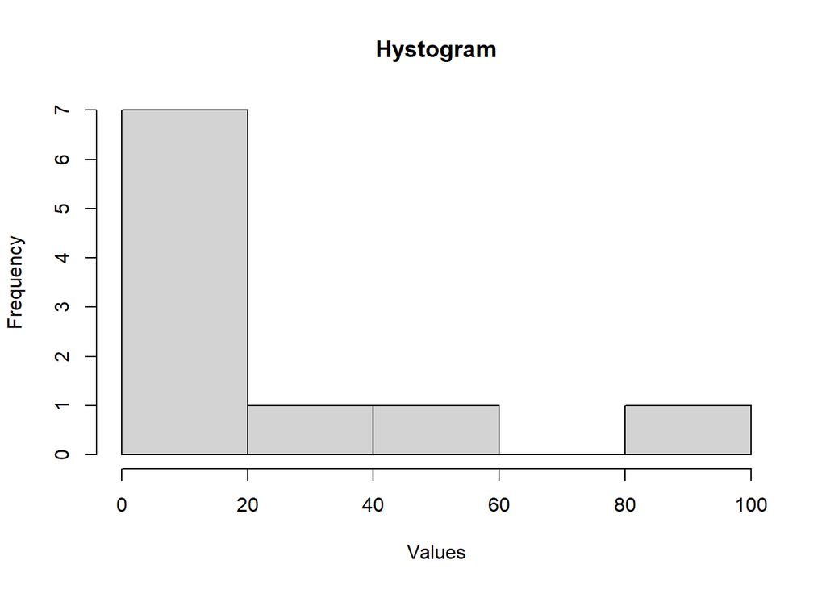

```r
# Format: hist(df, main = histogram_title, xlab = "x_axis_label", col = "column_color", border = "border_color")
data <- c(1,2,3,4,5,10,20,30,50,100)

hist(data, main = "Hystogram", xlab = "Values", col = "lightgrey", border = "black")
```

## Box Plots

### Overview

Box plots are very similar to histograms, except that multiple intervals can be displayed in one graph. This makes it useful for researchers, as it can display a lot of information in a single image.[^19]. It’s basically a simplified version of the data presented in multiple histograms. Box plots don’t make assumptions on the distribution of the data, making it nonparametric.

Here is a link to an image of a typical box plot: https://i0.wp.com/statisticsbyjim.com/wp-content/uploads/2019/01/boxplot_teaching.png?w=576&ssl=1

### Terms to Know

- Box plots outline their central tendencies and spreads through the **5-number summary**, which consist of:
  - **Minimum**: The smallest number in the interval’s data set.
  - **First quartile**: The value that separates the bottom 25% of values from the rest of the data.
  - **Median**: The middle value of the data set. Can also be called the **second quartile**.
  - **Third quartile**: The value that separates the bottom 75% of values from the rest of the data.
  - **Maximum**: The largest number in the data set.

### Coding Process

We can code for a box plot with the **boxplot()** function and writing something along these lines:

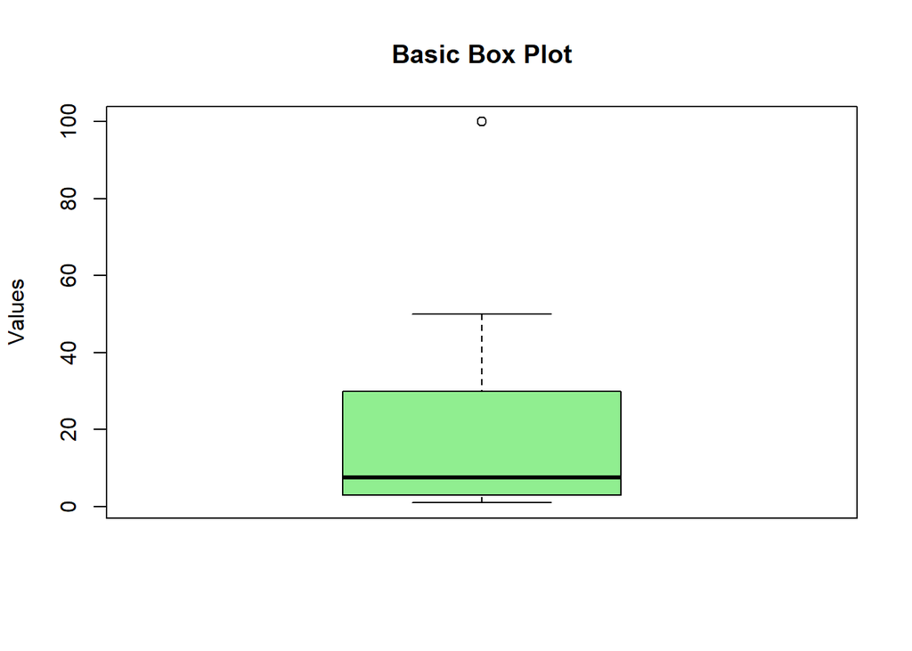

```r
# Format: boxplot(df, main = "boxplot_title", ylab = "y_axis_label", col = "column_color")
data <- c(1,2,3,4,5,10,20,30,50,100)

boxplot(data, main = "Basic Box Plot", ylab = "Values", col = "lightgreen")
```

For multiple groups of data, we can do something like this:

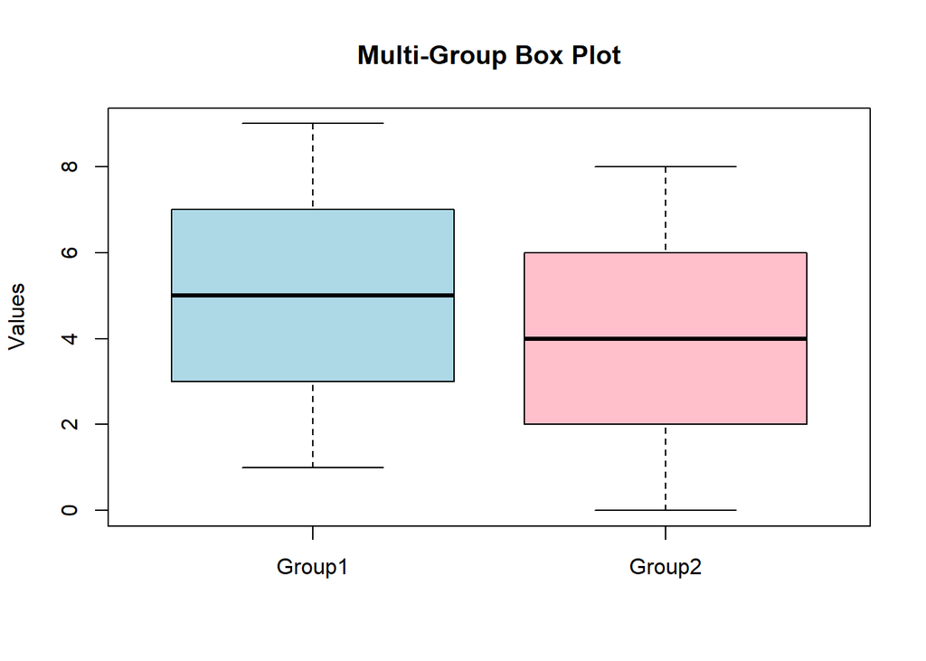

```r
group1 <- c(1,3,5,7,9)
group2 <- c(0,2,4,6,8)

data_list <- list(Group1 = group1, Group2 = group2)

boxplot(data_list, main = "Multi-Group Box Plot", ylab = "Values", col = c("lightblue", "pink"))
```

## Heat Maps

### Overview

Heat maps are typically used with large sets of data, all with values that can differ to various intensities.[^20] This data visualization technique will chart the data in a color-coded fashion, according to a spectrum of values. Heat maps are typically displayed in a **2d or 3d** matrix, and use a range of values as a reference point for a color spectrum.

For example, a heat map can graph the temperature distribution of a given area, with a spectrum ranging from red to blue; Redder colors are higher temperatures, while bluer colors are lower. The axes can represent the physical area the temperatures are being recorded over.

Here is an example of a typical 2-dimensional heat map… https://www.researchgate.net/publication/344202320/figure/fig5/AS:959980165414946@1605888515416/A-heat-map-of-the-two-dimensional-hierarchical-cluster-analysis-suggesting-differential.png

…As well as an example of a 3-dimensional one: https://drjohnsullivan.com/wp-content/uploads/2016/04/heat-map.jpg

### Terms to Know

- Some terms that are useful to know about when dealing with heat maps are:
  - **Matrix**: The area the axes give rise to. This can be either a 2 or 3-dimensional space where the values are plotted out.
  - **Spectrum**: The range of values being depicted in the heat map’s matrix, being displayed as a literal color spectrum.
  - **Clustering**: The property of a heat map that helps group similar rows and columns together. Depicted as tree-like structures on the side of the matrix.

### Coding Process

Heat maps can be coded for in R using the **heatmap()** function, and by writing the following:

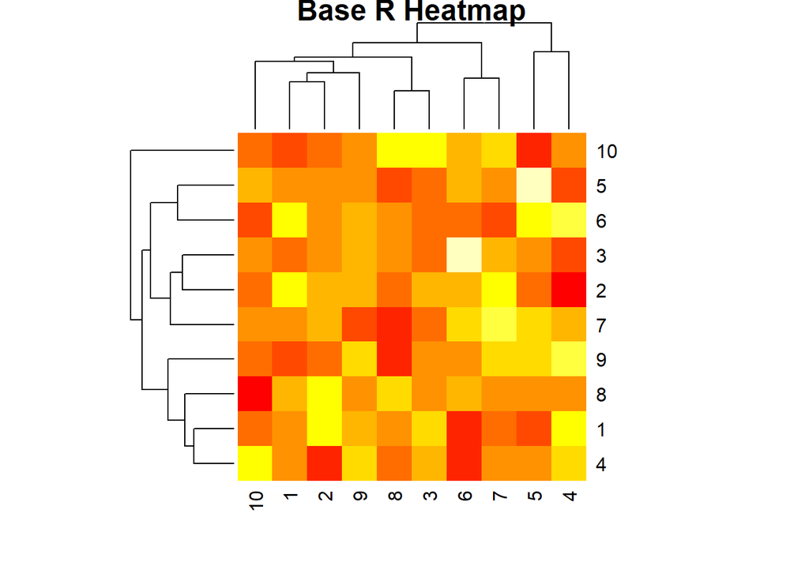

```r
# Format: heatmap(df, main = "heatmap_title", col = heat.colors(n))
data <- matrix(rnorm(100), nrow = 10)

heatmap(data, main = "Base R Heatmap", col = heat.colors(10))
```

The **ggplot2** package, if installed, can be used to create plots with more customization options, including heat maps, with the use of the **ggplot()** function.

These are just placeholder values; You can plug any number/color you need to properly display your data.

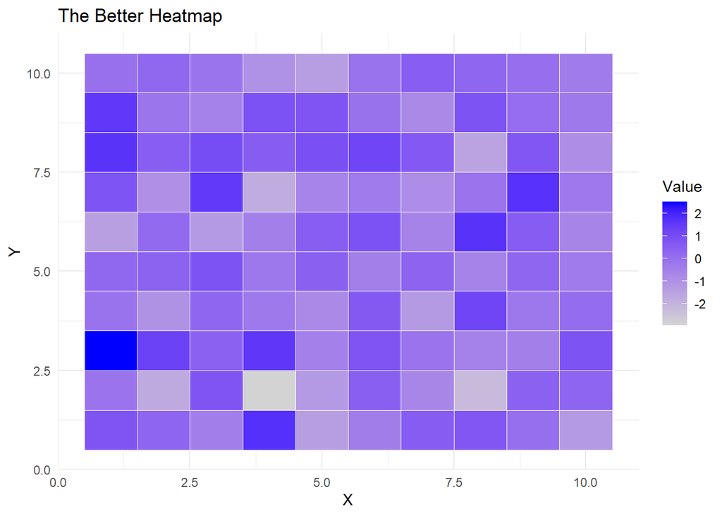

```r
library(ggplot2)

data <- expand.grid(X = 1:10, Y = 1:10)
data$Value <- rnorm(100)

ggplot(data, aes(x = X, y = Y, fill = Value)) +
  geom_tile(color = "white") +
  scale_fill_gradient(low = "lightgrey", high = "blue") +
  labs(title = "The Better Heatmap") +
  theme_minimal()
```

## Pie Charts

### Overview

Pie charts are likely one of the first data visualization methods one will use. This can be chalked up to their ease of use; However, they tend to be one of the most misused. [^21] A pie chart consists of a circle, with categorical data being represented on it as “slices.” Larger slices mean it takes up a larger portion of a single population/variable.

These charts can come in a variety of shapes, such as rings and bars.

Here is an example of one: https://images.squarespace-cdn.com/content/v1/55b6a6dce4b089e11621d3ed/1589459527969-AMZ4OHKJ5ES2GLYKK9WV/2_sales+by+product.png?format=1000w

### Terms to Know

- Some terms to know when dealing with pie charts are:
  - **Slice**: The portion of a whole variable a singular piece of categorical data takes up, visually represented. Its size can also depict frequency something happens in one instance.
  - **Pie**: The whole variable/population/instance. A typical pie represents **one** of these. Another type of chart would be needed if you were plotting categorical data across an interval.

### Coding Process

Unsurprisingly, there is a dedicated function in Base R for the creation of pie charts: **pie()**. Here’s how you could create one:

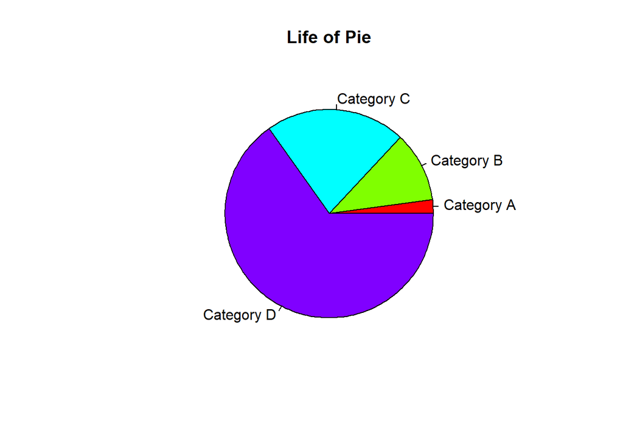

```r
# Format: pie(slices_list, labels = labels_list, main = "pie_chart_title", col = "column_color")
# column_color can be a gradient, based on the slices' length. This is indicated by the modified argument "gradient_color(length(slices))"
slices <- c(1,5,10,30)
labels <- c("Category A", "Category B", "Category C", "Category D")

pie(slices, labels = labels, main = "Life of Pie", col = rainbow(length(slices)))
```

In this instance, the pie chart will have differently-colored slices, the number of colors corresponding to the number of slices. This was indicated by the “col = rainbow(length(slices))” argument within the function.

# Conclusion

And there you have it! There are a variety of ways in which a statistician can gather and process data to prove a point. Each test has a rich history of use, with their creators working tirelessly to finalize their methods. There are equally as many ways to visualize this data as there are methods to process it as well, each with unique conditions for use. I hope this notebook was illuminating for you; I will also be keeping this handy for future reference.

While base R has plenty of methods by which we can organize and evaluate raw data, it can be helpful to go ahead and install some packages, such as ggplot2 and plotrix. This way, we aren’t spending as much time creating a formula for a specific statistical test from scratch.

[^1]: https://www.statisticshowto.com/probability-and-statistics/t-test/#assump
[^2]: https://statisticsbyjim.com/hypothesis-testing/wilcoxon-signed-rank-test/
[^3]: https://online.stat.psu.edu/stat415/lesson/20/20.2
[^4]: https://researchmethod.net/anova/
[^5]: https://www.britannica.com/topic/variance-analysis-statistics
[^6]: https://statisticsbyjim.com/glossary/explanatory-variable/
[^7]: https://statisticsbyjim.com/glossary/response-variable/
[^8]: https://statisticsbyjim.com/regression/linear-regression/#google_vignette
[^9]: https://stats.libretexts.org/Bookshelves/Introductory_Statistics/Mostly_Harmless_Statistics_(Webb)/12%3A_Correlation_and_Regression/12.02%3A_Simple_Linear_Regression/12.2.01%3A_Hypothesis_Test_for_Linear_Regression
[^10]: https://stats.libretexts.org/Courses/Rio_Hondo_College/Math_130%3A_Statistics/11%3A_Correlation/11.03%3A_Correlation_Hypothesis_Test
[^11]: https://usq.pressbooks.pub/statisticsforresearchstudents/chapter/correlation-assumptions/
[^12]: https://www.statology.org/when-to-use-correlation/
[^13]: **Both variables have the same direction, but rates of change may differ.**
[^14]: **Any data that has a natural, ordered sequence.**
[^15]: https://courses.lumenlearning.com/introstats1/chapter/null-and-alternative-hypotheses/
[^16]: https://www.investopedia.com/terms/p/p-value.asp
[^17]: https://www.geeksforgeeks.org/maths/histogram/
[^18]: https://statisticsbyjim.com/basics/histograms/
[^19]: https://statisticsbyjim.com/graphs/box-plot/
[^20]: https://www.geeksforgeeks.org/data-visualization/what-is-heatmap-data-visualization-and-how-to-use-it/
[^21]: https://www.storytellingwithdata.com/blog/2020/5/14/what-is-a-pie-chart